# 16S_DataImport_Transformations_Export

Jake Nash

2024-09-27

## Load Required Packages

```r
library(tidyverse)
library(vegan)
library(magrittr)
library(tibble)
```

## Import taxonomy file and parse taxonomy string into separate columns

```r
extract_text <- function(x) {
  sub(".+__", "", x)
}

TaxMat16S_SILVA=
  read_tsv("../Aus23_16S_Metabarcoding/Aus23_16S_SilvaTaxonomy_16S.tsv") %>%
  rename("otu"="Feature ID") %>%
  select(-Confidence) %>%
  separate_wider_delim(too_few="align_start", cols = Taxon, delim = ";", names = c("Kingdom", "Phylum","Class", "Order","Family","Genus","Species", "SH")) %>%
  mutate(across(!contains("otu"), ~extract_text(.)))
```

## Import ASV table

```r
OtuMat16S=
  read_tsv("../Aus23_16S_Metabarcoding/Aus23_16S_ASV_table.tsv", skip=1) %>%
  column_to_rownames("#OTU ID")
```

## Import Metadata

```r
Metadata_16S=
  read_tsv("../Aus23_16S_Metabarcoding/MetabarcodingMetadata.txt") %>%
  slice(-1) %>% #remove the comment row
  rename("SampleID"=`sample-id`) %>% #rename SampleID column
    mutate(TreeSampleType = gsub("-.", "", SampleID)) #generate new column with Tree ID and sample type concatenated

Metadata_16S_pooled=
  Metadata_16S %>%
  distinct(TreeSampleType, .keep_all = TRUE)
```

## Removes ASVs that were identified as chloroplast/mitochondria

First generates list of 16S ASVs that are organellar based on SILVA taxonomy

Then filters out lines from OTU table that match those ASVs

```r
ASV_mito_chloro_list=
  TaxMat16S_SILVA %>%
  filter((Order=="Chloroplast" |
            Family=="Mitochondria")) %$%
  otu

OtuMat16S_filter=
  OtuMat16S %>%
  filter(!(rownames(.) %in% ASV_mito_chloro_list))
```

## Calculates sequencing depth per sample, then rarefies to 24860

Sequencing depth is check for OTU table both before and after removing mitochondrial/chloroplast sequences. We then calculate the percentage of sequences filtered from each sample. We find that eucalyptus root samples have the highest percentage sequneces being removed, likely due to mismatch with the PNA blockers.

Rarefaction is then performed on OTU table that has had mitochondria and chloroplasts filtered.

Rarefaction curves are generated showing rarefaction point as dotted line. Rarefaction resulted in dropping sample P3-2_Root and the negative control. OTUs that had 0 sequences remaining after rarefaction were removed. Random seed was set to ensure reproducibility

```r
#calculates sequencing depth by taking column sums of OTU table
SeqDepth16S_nonplastid=
  OtuMat16S_filter %>%
  colSums() %>%
  as.data.frame %>%
  set_colnames("n_sequences_nonplastid") %>%
  mutate(SampleID=rownames(.))

SeqDepth16S=
  OtuMat16S %>%
  colSums() %>%
  as.data.frame %>%
  set_colnames("n_sequences") %>%
  mutate(SampleID=rownames(.)) %>%
  left_join(SeqDepth16S_nonplastid) %>%
  mutate(SeqDiscard=n_sequences-n_sequences_nonplastid,
         PercDiscard=100*SeqDiscard/n_sequences)
```

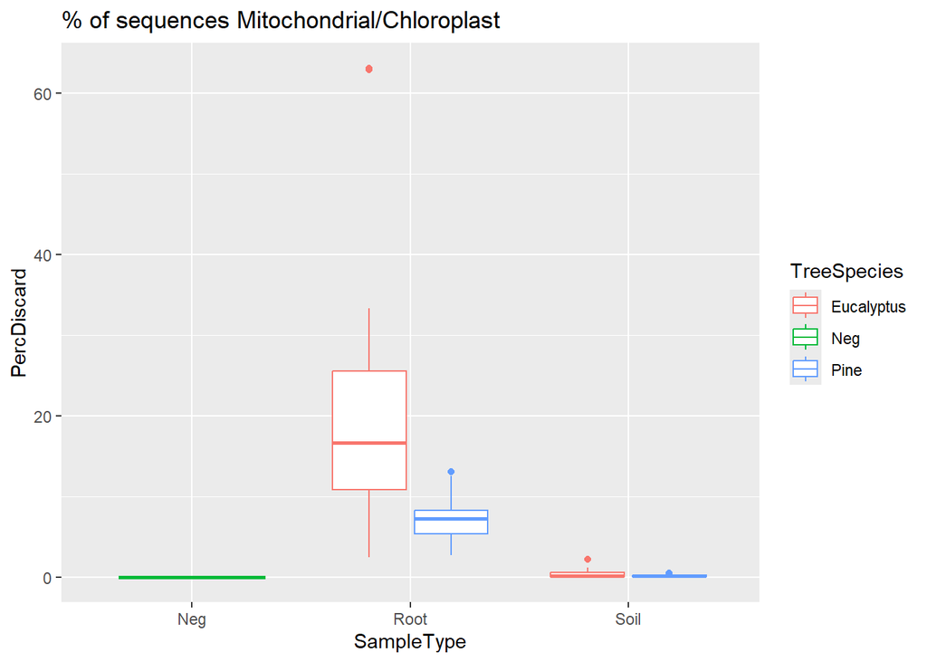

```r
SeqDepth16S %>%
  left_join(Metadata_16S) %>%
  ggplot(aes(x=SampleType, y=PercDiscard, color=TreeSpecies)) +
  geom_boxplot() +
  ggtitle("% of sequences Mitochondrial/Chloroplast")
```

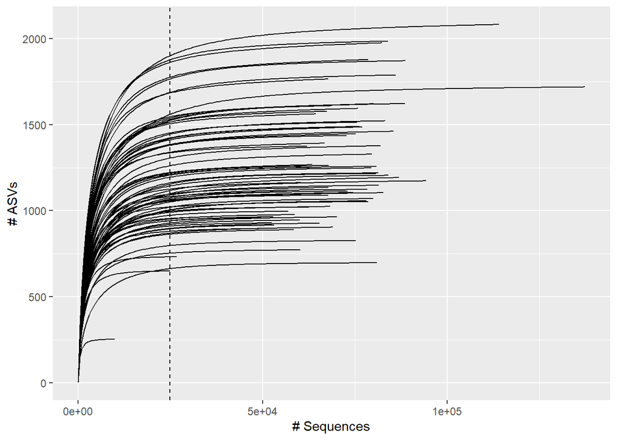

```r
#uses vegan function to generate rarefaction curve dataframe using a step of 500 seqs
RareCurve_16S=
  OtuMat16S_filter %>%
  t %>%
  rarecurve(step=500, tidy=TRUE)

#sets rarefaction depth to 24,860 seqs, based on seq depth dataframe
rare_depth_16S=24860
#plots rarefaction curve, drawing a vertical line at the rarefaction depth
ggplot(RareCurve_16S, aes(x=Sample, y=Species, group=Site)) +
  geom_line() +
  geom_vline(xintercept=rare_depth_16S, linetype=2) +
  ylab("# ASVs") +
  xlab("# Sequences")
```

```r
set.seed(2023) #make sure to set the random seed so that rarefaction is reproducible

#uses vegan rarefaction function to rarefy to previously defined rarefaction depth
OtuMat16S_rare=
  OtuMat16S_filter %>%
  t %>%
  as.data.frame %>%
  rrarefy(sample=rare_depth_16S) %>%
  as.data.frame %>%
  select(-which(colSums(.) == 0)) %>%
  filter(rowSums(.) >= rare_depth_16S)
```

## Generates an OTU table where replicates from the same tree are pooled

This is done by taking the rarefied OTU table, then summing together the sequence counts for both replicates from each tree. For the soil samples, this means summing together the north and south plots, and for the root samples this means summing together the 2 PCR technical replicates

```r
OtuMat16S_rare_pooled=
  OtuMat16S_rare %>%
  mutate(TreeSampleType = gsub("-.", "", rownames(.))) %>% #make a new column with the tree ID and sample type
  group_by(TreeSampleType) %>% #group dataframe by tree ID and sample type
  summarise(across(everything(), sum, .names = "{.col}")) %>% #sum together sequence counts for all samples that were from the same tree and sample type
  column_to_rownames("TreeSampleType") #set rownames to tree ID_sample type
```

## Generates relative abundance OTU table versions of the unpooled and pooled rarefied tables

This is done by dividing each OTU’s sequence count by the total sequence count for that sample. This makes it so that all rows sum to 1

```r
OtuMat16S_rare_pooled_rel=
  OtuMat16S_rare_pooled %>%
  sweep(1, rowSums(.), FUN = "/")  # do compositional data transform

OtuMat16S_rare_rel=
  OtuMat16S_rare %>%
  sweep(1, rowSums(.), FUN = "/")  # do compositional data transform

OtuMat16S_rel=
  OtuMat16S_filter %>%
  t %>%
  as.data.frame %>%
  sweep(1, rowSums(.), FUN = "/") # do compositional data transform

OtuMat16S_pooled_rel=
  OtuMat16S_filter %>%
  t %>%
  as.data.frame %>%
  mutate(TreeSampleType = gsub("-.", "", rownames(.))) %>% #make a new column with the tree ID and sample type
  group_by(TreeSampleType) %>% #group dataframe by tree ID and sample type
  summarise(across(everything(), sum, .names = "{.col}")) %>% #sum together sequence counts for all samples that were from the same tree and sample type
  column_to_rownames("TreeSampleType") %>% #set rownames to tree ID_sample type
  sweep(1, rowSums(.), FUN = "/")  # do compositional data transform
```

## Generates Aitchison distance matrices

This is done on both the pooled and unpooled versions of the OTU table, both unrarefied and relativized versions

A pseudocount value of 1 is used for the log transform

```r
Aitchison_unpooled_rel_16S=vegdist(OtuMat16S_rel, method = "aitchison", pseudocount=1)

Aitchison_pooled_rel_16S=vegdist(OtuMat16S_pooled_rel, method = "aitchison", pseudocount=1)
```

## Generates alpha diversity dataframe for pooled and unpooled rarefied OTU tables

```r
AlphaDiv_16S=
  data.frame(Shannon=diversity(OtuMat16S_rare, index="shannon"),
             Simpson=diversity(OtuMat16S_rare, index="simpson"),
             Invsimpson=diversity(OtuMat16S_rare, index="invsimpson"),
             Richness=specnumber(OtuMat16S_rare)) %>%
  mutate(SampleID=rownames(.)) %>%
  left_join(Metadata_16S)

AlphaDiv_pooled_16S=
  data.frame(Shannon=diversity(OtuMat16S_rare_pooled, index="shannon"),
             Simpson=diversity(OtuMat16S_rare_pooled, index="simpson"),
             Invsimpson=diversity(OtuMat16S_rare_pooled, index="invsimpson"),
             Richness=specnumber(OtuMat16S_rare_pooled)) %>%
  mutate(TreeSampleType=rownames(.)) %>%
  left_join(Metadata_16S_pooled)
```

## Generates guild summaries based on bacterial copiotroph/oligotroph assignments

Generate relative abundances of guild by sample (using the relative abundance OTU table) and generate richness of each guild by sample (using the rarefied OTU table). (This chunk edited by Corinne on 10/17/24)

```r
# read in taxonomy appended with guilds
TaxGuild <- read.csv("../Aus23_16S_Metabarcoding/Taxonomy/Aus23_16S_SilvaTaxonomy_FunctionalGuilds.csv", row.names=1)[c(6,21)]

############# UN-POOLED DATA ########################

# Calculate relative abundances of copiotrophs and oligotrophs
guild_summary_16S=
  OtuMat16S_rel %>%
  t %>%
  as.data.frame %>%
  mutate(otu=rownames(.)) %>%
  left_join(TaxGuild, by="otu") %>%
  mutate(guild_edited=
           case_when(
             Copio_oligo=="Oligotroph" ~ "Oligotroph_rel_abund",
             Copio_oligo=="Copiotroph" ~ "Copiotroph_rel_abund",
             )) %>%
  select(-Copio_oligo, -otu) %>%
  group_by(guild_edited) %>%
  summarise(across(everything(), sum, na.rm = TRUE))
guild_summary_16S[3,1] <- "OtherBacteria_rel_abund"
guild_summary_16S_final <- guild_summary_16S[,c(2:ncol(guild_summary_16S))]
rownames(guild_summary_16S_final) <- guild_summary_16S$guild_edited
guild_summary_16S_final <- as.data.frame(t(guild_summary_16S_final))


# Calculate richness of copiotrophs and oligotrophs
guild_richness_16S=
  OtuMat16S_rare %>%
  mutate_all(~ ifelse(. > 0, 1, .)) %>% #converts dataframe to presence/absense. Present=1, Absent=0
  t %>%
  as.data.frame %>%
  mutate(otu=rownames(.)) %>%
  left_join(TaxGuild, by="otu") %>%
  mutate(guild_edited=
           case_when(
             Copio_oligo=="Oligotroph" ~ "Oligotroph_richness",
             Copio_oligo=="Copiotroph" ~ "Copiotroph_richness",
             )) %>%
  select(-Copio_oligo, -otu) %>%
  group_by(guild_edited) %>%
  summarise(across(everything(), sum, na.rm = TRUE))

guild_richness_16S[3,1] <- "OtherBacteria_richness"
guild_richness_16S_final <- guild_richness_16S[,c(2:ncol(guild_richness_16S))]
rownames(guild_richness_16S_final) <- guild_richness_16S$guild_edited
guild_richness_16S_final <- as.data.frame(t(guild_richness_16S_final))

############# POOLED DATA ########################

# Calculate relative abundances of copiotrophs and oligotrophs
guild_summary_16S_pool=
  OtuMat16S_pooled_rel %>%
  t %>%
  as.data.frame %>%
  mutate(otu=rownames(.)) %>%
  left_join(TaxGuild, by="otu") %>%
  mutate(guild_edited=
           case_when(
             Copio_oligo=="Oligotroph" ~ "Oligotroph_rel_abund",
             Copio_oligo=="Copiotroph" ~ "Copiotroph_rel_abund",
             )) %>%
  select(-Copio_oligo, -otu) %>%
  group_by(guild_edited) %>%
  summarise(across(everything(), sum, na.rm = TRUE))
guild_summary_16S_pool[3,1] <- "OtherBacteria_rel_abund"
guild_summary_16S_pool_final <- guild_summary_16S_pool[,c(2:ncol(guild_summary_16S_pool))]
rownames(guild_summary_16S_pool_final) <- guild_summary_16S_pool$guild_edited
guild_summary_16S_pool_final <- as.data.frame(t(guild_summary_16S_pool_final))


# Calculate richness of copiotrophs and oligotrophs
guild_richness_16S_pool=
  OtuMat16S_rare_pooled %>%
  mutate_all(~ ifelse(. > 0, 1, .)) %>% #converts dataframe to presence/absense. Present=1, Absent=0
  t %>%
  as.data.frame %>%
  mutate(otu=rownames(.)) %>%
  left_join(TaxGuild, by="otu") %>%
  mutate(guild_edited=
           case_when(
             Copio_oligo=="Oligotroph" ~ "Oligotroph_richness",
             Copio_oligo=="Copiotroph" ~ "Copiotroph_richness",
             )) %>%
  select(-Copio_oligo, -otu) %>%
  group_by(guild_edited) %>%
  summarise(across(everything(), sum, na.rm = TRUE))

guild_richness_16S_pool[3,1] <- "OtherBacteria_richness"
guild_richness_16S_pool_final <- guild_richness_16S_pool[,c(2:ncol(guild_richness_16S_pool))]
rownames(guild_richness_16S_pool_final) <- guild_richness_16S_pool$guild_edited
guild_richness_16S_pool_final <- as.data.frame(t(guild_richness_16S_pool_final))
```

## Merging richness with guild summary data

```r
AlphaDivGuilds16S=
  AlphaDiv_16S %>%
  left_join((guild_summary_16S_final %>% mutate(SampleID=rownames(.)))) %>%
  left_join((guild_richness_16S_final %>% mutate(SampleID=rownames(.))))

AlphaDivGuilds16S_pooled=
  AlphaDiv_pooled_16S %>%
  left_join((guild_summary_16S_pool_final %>% mutate(TreeSampleType=rownames(.)))) %>%
  left_join((guild_richness_16S_pool_final %>% mutate(TreeSampleType=rownames(.))))
```

## Saving/exporting files as csv’s

OTU tables and distance matrices are saved as csv’s so that they can easily be used in other analyses.

```r
filepath="../Aus23_16S_Metabarcoding/OTUTables/"

# OTU tables
write.csv(OtuMat16S_filter, paste(filepath, "OtuMat16S_filter.csv", sep=""))

write.csv(OtuMat16S_rare, paste(filepath, "OtuMat16S_rare.csv", sep=""))
write.csv(OtuMat16S_rare_rel, paste(filepath, "OtuMat16S_rare_rel.csv", sep=""))
write.csv(OtuMat16S_rare_pooled, paste(filepath, "OtuMat16S_rare_pooled.csv", sep=""))
write.csv(OtuMat16S_rare_pooled_rel, paste(filepath, "OtuMat16S_rare_pooled_rel.csv", sep=""))

write.csv(OtuMat16S_rel, paste(filepath, "OtuMat16S_rel.csv", sep=""))
write.csv(OtuMat16S_pooled_rel, paste(filepath, "OtuMat16S_pooled_rel.csv", sep=""))

write.csv(as.matrix(Aitchison_unpooled_rel_16S), paste(filepath, "Aitchison_unpooled_rel_16S.csv", sep=""))
write.csv(as.matrix(Aitchison_pooled_rel_16S), paste(filepath, "Aitchison_pooled_rel_16S.csv", sep=""))

# Alpha diversity + guild data
write.csv(AlphaDivGuilds16S, paste(filepath, "AlphaDivGuilds16S.csv", sep=""))
write.csv(AlphaDivGuilds16S_pooled, paste(filepath, "AlphaDivGuilds16S_pooled.csv", sep=""))
```